# Plotting Grab Bag

For a relaxed meetup before Thanksgiving, we’ll take a look at some useful plot code that’s more specific for academic and biological representations.

## `cowplot`

`cowplot` goes on top of `ggplot` to create publication-ready plots. It has some minor tweaks to the default `ggplot` theme, but what most people use it for is to arrange plots in a grid.

If you haven’t already, install `cowplot` by uncommenting the code in the chunk below and running its.

```r
#install.packages('cowplot')
```

**Make a bunch of plots** for making a grid in the next chunk.

```r
# sepal length vs sepal width
ggplot(iris, aes(x = Sepal.Length, y = Sepal.Width, color = Species)) +
  geom_point(size = 3) +
  labs(x = 'Sepal Length (cm)', y = 'Sepal Width (cm)') +
  theme_classic() -> iris1

# sepal length vs petal length
ggplot(iris, aes(x = Sepal.Length, y = Petal.Length, color = Species)) +
  geom_point(size = 3) +
  labs(x = 'Sepal Length (cm)', y = 'Petal Length (cm)') +
  theme_classic() -> iris2

# sepal length vs petal width
ggplot(iris, aes(x = Sepal.Length, y = Petal.Width, color = Species)) +
  geom_point(size = 3) +
  labs(x = 'Sepal Length (cm)', y = 'Petal Width (cm)') +
  theme_classic() -> iris3
```

**Plot together** using `cowplot::plot_grid()`

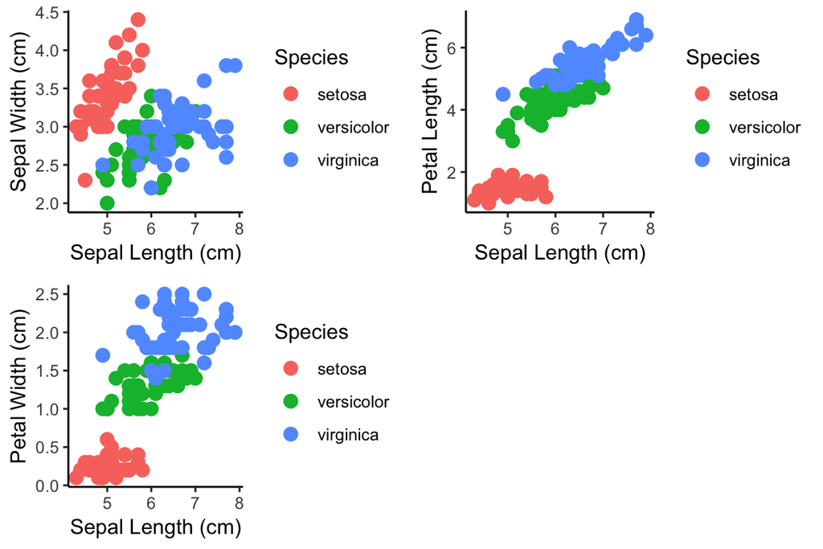

```r
# basic
plot_grid(iris1, iris2, iris3)
```

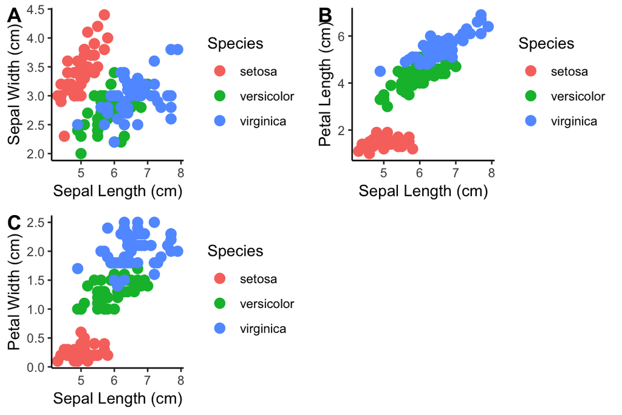

```r
# add labels
plot_grid(iris1, iris2, iris3, labels = c('A', 'B', 'C'))
```

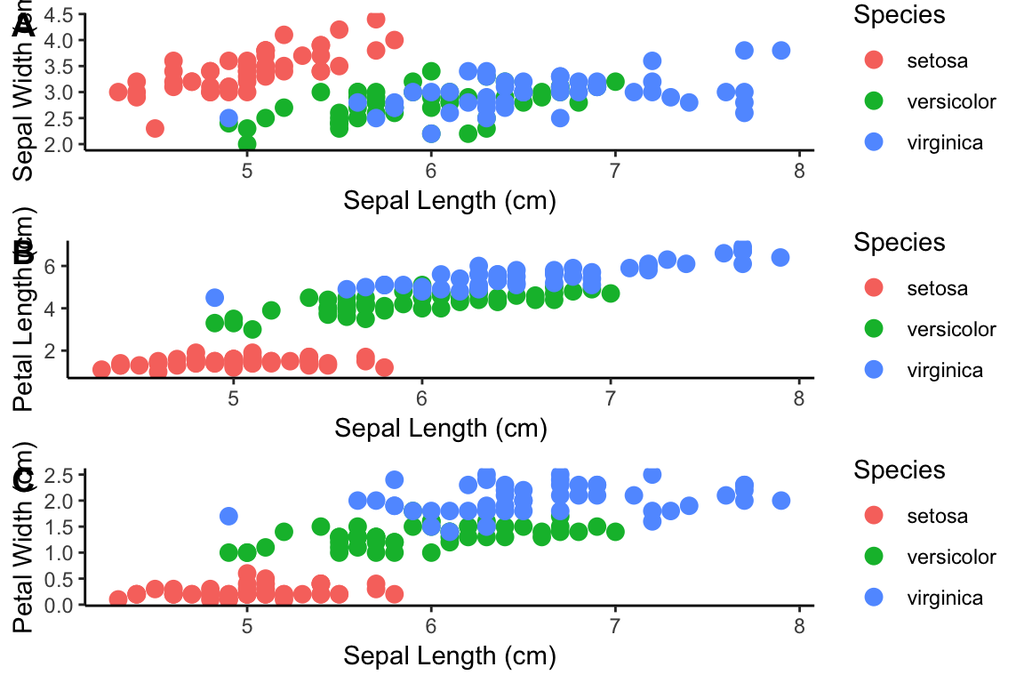

```r
# specify number of columns/rows
plot_grid(iris1, iris2, iris3, labels = c('A', 'B', 'C'), ncol = 1)
```

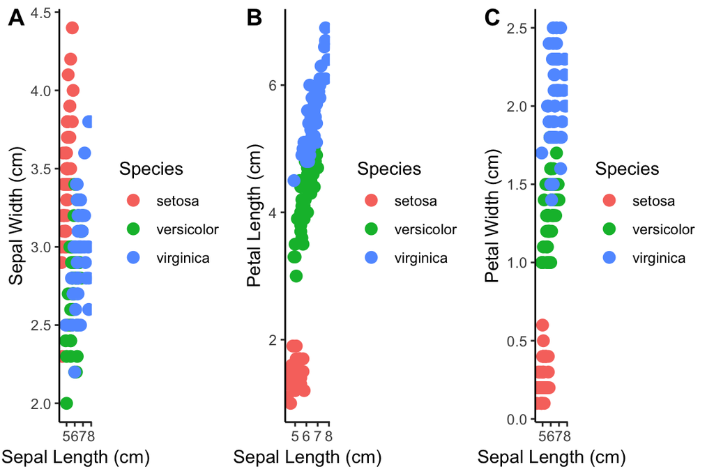

```r
plot_grid(iris1, iris2, iris3, labels = c('A', 'B', 'C'), nrow = 1)
```

## Plotting Differential Expression

We’re going to practice plotting a volcano plot and an MA plot for differential expression.

First, read in a fake-ish differential expression table to practice plotting with. (Counts are from the gilad count table downloaded from the ReCount RNAseq website http://bowtie-bio.sourceforge.net/recount/)

```r
diff_exp <- read_tsv('demo_diff_exp_tbl.tsv')
```

### Volcano Plot

**Wrangle table before plotting**

A volcano plot has log2 fold change in RNA expression on the x axis vs. negative log10 p-values on the y-axis with points colored by significance of the p-value. This means we need three columns to plot:

1. log2 fold change in expression (logFC)
2. -log10 pvalues
3. a categorical column for coloring by significance

Log2 fold change is usually returned by differential expression packages and is in our table, the logFC column. However, we only have p-values in their normal small decimal format. They can be converted into -log10 inside of ggplot, but it makes plotting faster to add a column to the table first. Then we can add a categorical significance column for coloring by.

```r
diff_exp %>%
  mutate(log_pvalue = -log10(PValue),
         significant = ifelse(-log10(PValue) > -log10(0.05) & (logFC < -2 | logFC > 2),
                              'sig', 'notsig')) -> diff_exp_volcplot
```

**Plot a volcano plot**

[figure not shown]

```r
ggplot(diff_exp_volcplot, aes(x = logFC, y = log_pvalue)) +
  geom_point(aes(color = significant)) +
  scale_color_manual(name = '',
                     values = c('black', 'red'),
                     labels = c('significant (< 0.05)', 'not significant')) +
  geom_hline(yintercept = -log10(0.05),
             linetype = 'dashed',
             color = 'grey40') +
  geom_vline(xintercept = c(-2, 2),
             linetype = 'dashed',
             color = 'grey40') +
  labs(x = 'Log2 Fold Change in Expression', y = '-Log10 P-Value') +
  theme_classic() +
  theme(axis.title = element_text(size = 14),
        legend.text = element_text(size = 12))
```

### MA Plot

**Wrangle table before plotting**

An MA plot has average expression on the x axis and log fold change in expression on the y axis. This means the three columns we need to plot are:

1. mean expression
2. log2 fold change in expression (logFC)
3. a categorical column for coloring by significance

```r
# tidy calculation
diff_exp %>%
  mutate(significant = ifelse(-log10(PValue) > 2 & (logFC < -2 | logFC > 2),
                              'sig', 'notsig')) -> diff_exp_maplot
```

**Plot**

[figure not shown]

```r
ggplot(diff_exp_maplot, aes(x = logCPM, y = logFC)) +
  geom_point(aes(color = significant)) +
  scale_color_manual(values = c('black', 'red'),
                     labels = c('significant', 'not significant')) +
  geom_hline(yintercept = c(-2, 0, 2),
             linetype = c('dashed', 'solid', 'dashed'),
             color = c('grey40', 'red', 'grey40')) +
  labs(x = 'Mean Expression (log10 Counts per Million Reads)',
       y = 'Log2 Fold Change in Expression') +
  theme_classic() +
  theme(legend.title = element_blank(),
        axis.title = element_text(size = 14),
        legend.text = element_text(size = 12))
```